# Introduction to outbreaker2

Thibaut Jombart

2025-12-16

This tutorial provides a worked example of outbreak reconstruction using *outbreaker2*. For installation guidelines, a general overview of the package’s functionalities as well as other resources, see the ‘overview’ vignette:

```r
vignette("Overview", package = "outbreaker2")
```

We will be analysing a small simulated outbreak distributed with the package, `fake_outbreak`. This dataset contains simulated dates of onsets, partial contact tracing data and pathogen genome sequences for 30 cases:

```r
library(ape)
library(outbreaker2)

col <- "#6666cc"
fake_outbreak
```

```
#> $onset
#>  [1]  0  2  4  4  6  6  6  7  7  8  8  8  8  9  9  9  9 10 10 10 10 10 10 10 10
#> [26] 10 10 10 11 11
#>
#> $sample
#>  [1]  3  5  6  6  7  9  8  9  9  9 11 10 10 10 10 11 11 12 11 13 12 13 11 12 11
#> [26] 11 13 12 14 14
#>
#> $dna
#> 30 DNA sequences in binary format stored in a matrix.
#>
#> All sequences of same length: 10000
#>
#> Labels:
#> ...
#>
#> Base composition:
#>     a     c     g     t
#> 0.251 0.242 0.251 0.256
#> (Total: 300 kb)
#>
#> $w
#> [1] 0.04255319 0.21276596 0.42553191 0.31914894
#>
#> $ances
#>  [1] NA  1  2 NA  3  4  4  5  6  6  7  8  9  5  5  7  7  8  9 10 11 11 13 13 13
#> [26] 17 17 NA 10 13
#>
#> $ctd
#>     i  j
#> 1   4  7
#> 2  10 29
#> 3  13 30
#> 4  11 22
#> 5  13 25
#> 6  16  7
#> 7  13 23
#> 8  10  6
#> 9  18  8
#> 10 14  5
```

[output cut: 10 more lines]

```
#> 21 17 20
#> 22 21 29
#> 23 11 14
#> 24 18  9
#> 25 25 29
#> 26  1 17
#> 27 23  7
#> 28 25  3
#> 29  3  9
#> 30  1  4
#> 31 13  4
#> 32 21 27
#> 33 16  2
#> 34 29  3
#> 35 21  5
```

Here, we will use the dates of case isolation `$sample`, DNA sequences `$dna`, contact tracing data `$ctd` and the empirical distribution of the generation time `$w`, which can be visualised as:

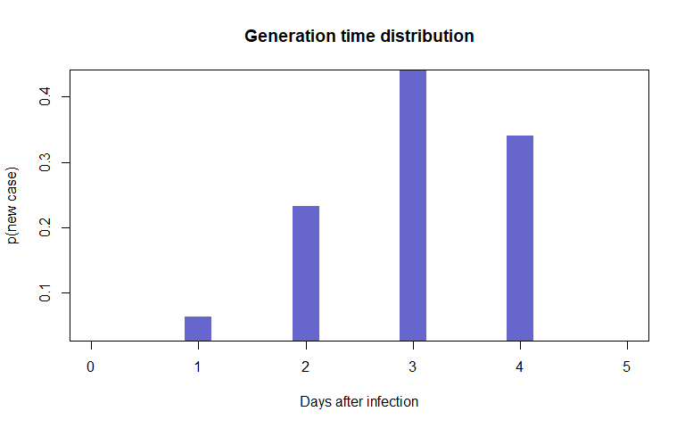

```r
plot(fake_outbreak$w, type = "h", xlim = c(0, 5),
     lwd = 30, col = col, lend = 2,
     xlab = "Days after infection",
     ylab = "p(new case)",
     main = "Generation time distribution")
```

# Running the analysis with defaults

By default, *outbreaker2* uses the settings defined by `create_config()`; see the documentation of this function for details. Note that the main function of *outbreaker2* is called `outbreaker` (without number). The function’s arguments are:

```r
args(outbreaker)
```

```
#> function (data = outbreaker_data(), config = create_config(),
#>     priors = custom_priors(), likelihoods = custom_likelihoods(),
#>     moves = custom_moves())
#> NULL
```

The only mandatory input really is the data. For most cases, customising the method will be done through `config` and the function `create_config()`, which creates default and alters settings such as prior parameters, length and rate of sampling from the MCMC, and definition of which parameters should be estimated (‘moved’). The last arguments of `outbreaker` are used to specify custom prior, likelihood, and movement functions, and are detailed in the ‘*Customisation*’ vignette.

Let us run the analysis with default settings:

```r
dna <- fake_outbreak$dna
dates <- fake_outbreak$sample
ctd <- fake_outbreak$ctd
w <- fake_outbreak$w
data <- outbreaker_data(dna = dna, dates = dates, ctd = ctd, w_dens = w)

## we set the seed to ensure results won't change
set.seed(1)

res <- outbreaker(data = data)
```

```
#> Identifying imports...
#>   |                                                          |                                                  |   1%  |                                                          |=                                                 |   2%  |                                                          …
#> Reconstructing transmission trees...
#>   |                                                          |                                                  |   0%  |                                                          |                                                  |   1%  |                                                          …
```

This analysis will take around 40 seconds on a modern computer. Note that *outbreaker2* is slower than *outbreaker* for the same number of iterations, but the two implementations are actually different. In particular, *outbreaker2* performs many more moves than the original package for each iteration of the MCMC, resulting in more efficient mixing. In short: *outbreaker2* is slower, but it requires far less iterations.

Results are stored in a `data.frame` with the special class `outbreaker_chains`:

```r
class(res)
```

```
#> [1] "outbreaker_chains" "data.frame"
```

```r
dim(res)
```

```
#> [1] 201  99
```

```r
res
```

```
#>
#>
#>  ///// outbreaker results ///
#>
#> class:  outbreaker_chains data.frame
#> dimensions 201 rows,  99 columns
#> ancestries not shown: alpha_3 - alpha_30
#> infection dates not shown: t_inf_1 - t_inf_30
#> intermediate generations not shown: kappa_1 - kappa_30
#>
#> /// head //
#>   step       post       like    prior           mu        pi alpha_1 alpha_2
#> 1    1 -1197.9116 -1199.2658 1.354240 0.0001000000 0.9000000      NA       1
#> 2   50  -558.8370  -560.8598 2.022727 0.0001599449 0.9694004      NA       1
#> 3  100  -531.6845  -533.3847 1.700200 0.0001466024 0.9352743      NA       1
#>
#> ...
#> /// tail //
#>      step      post      like    prior           mu        pi alpha_1 alpha_2
#> 199  9900 -529.3580 -530.7534 1.395326 0.0001321390 0.9041212      NA       1
#> 200  9950 -524.7793 -526.3679 1.588619 0.0001255888 0.9237484      NA       1
#> 201 10000 -524.1208 -526.2672 2.146385 0.0001625476 0.9828120      NA       1
```

Each row of `res` contains a sample from the MCMC. For each, informations about the step (iteration of the MCMC), log-values of posterior, likelihood and priors, and all parameters and augmented data are returned. Ancestries (i.e. indices of the most recent ancestral case for a given case), are indicated by `alpha_[index of the case]`, dates of infections by `t_inf_[index of the case]`, and number of generations between cases and their infector / ancestor by `kappa_[index of the case]`:

```r
names(res)
```

```
#>  [1] "step"     "post"     "like"     "prior"    "mu"       "pi"
#>  [7] "alpha_1"  "alpha_2"  "alpha_3"  "alpha_4"  "alpha_5"  "alpha_6"
#> [13] "alpha_7"  "alpha_8"  "alpha_9"  "alpha_10" "alpha_11" "alpha_12"
#> [19] "alpha_13" "alpha_14" "alpha_15" "alpha_16" "alpha_17" "alpha_18"
#> [25] "alpha_19" "alpha_20" "alpha_21" "alpha_22" "alpha_23" "alpha_24"
#> [31] "alpha_25" "alpha_26" "alpha_27" "alpha_28" "alpha_29" "alpha_30"
#> [37] "t_inf_1"  "t_inf_2"  "t_inf_3"  "t_inf_4"  "t_inf_5"  "t_inf_6"
#> [43] "t_inf_7"  "t_inf_8"  "t_inf_9"  "t_inf_10" "t_inf_11" "t_inf_12"
#> [49] "t_inf_13" "t_inf_14" "t_inf_15" "t_inf_16" "t_inf_17" "t_inf_18"
#> [55] "t_inf_19" "t_inf_20" "t_inf_21" "t_inf_22" "t_inf_23" "t_inf_24"
#> [61] "t_inf_25" "t_inf_26" "t_inf_27" "t_inf_28" "t_inf_29" "t_inf_30"
#> [67] "kappa_1"  "kappa_2"  "kappa_3"  "kappa_4"  "kappa_5"  "kappa_6"
#> [73] "kappa_7"  "kappa_8"  "kappa_9"  "kappa_10" "kappa_11" "kappa_12"
#> [79] "kappa_13" "kappa_14" "kappa_15" "kappa_16" "kappa_17" "kappa_18"
#> [85] "kappa_19" "kappa_20" "kappa_21" "kappa_22" "kappa_23" "kappa_24"
#> [91] "kappa_25" "kappa_26" "kappa_27" "kappa_28" "kappa_29" "kappa_30"
#> [97] "eps"      "lambda"   "eta"
```

# Analysing the results

## Graphics

Results can be visualised using `plot`, which has several options and can be used to derive various kinds of graphics (see `?plot.outbreaker_chains`). The basic plot shows the trace of the log-posterior values, which is useful to assess mixing:

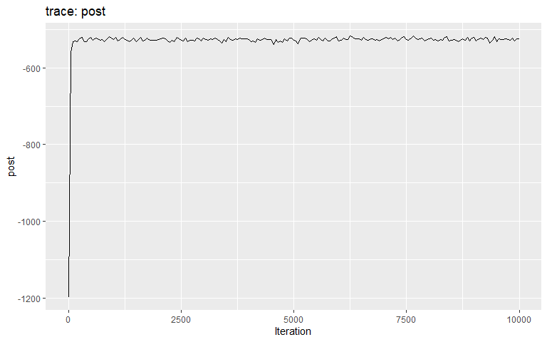

```r
plot(res)
```

The second argument of `plot` can be used to visualise traces of any other column in `res`:

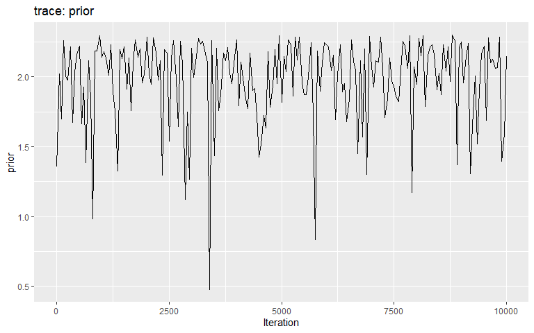

```r
plot(res, "prior")
```

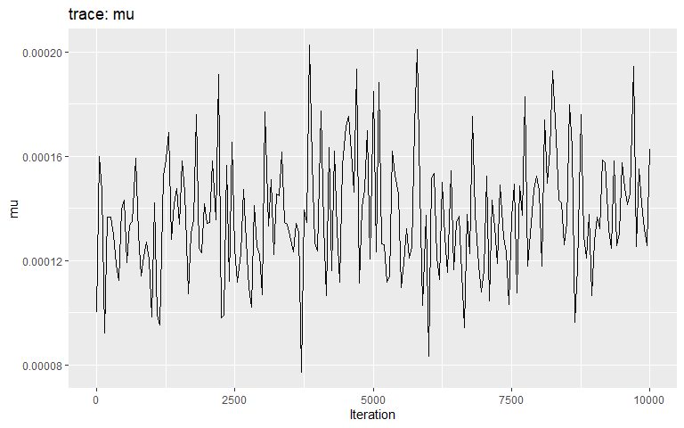

```r
plot(res, "mu")
```

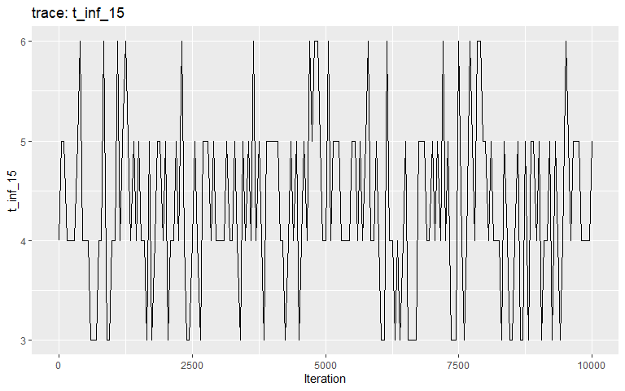

```r
plot(res, "t_inf_15")
```

`burnin` can be used to discard the first iterations prior to mixing:

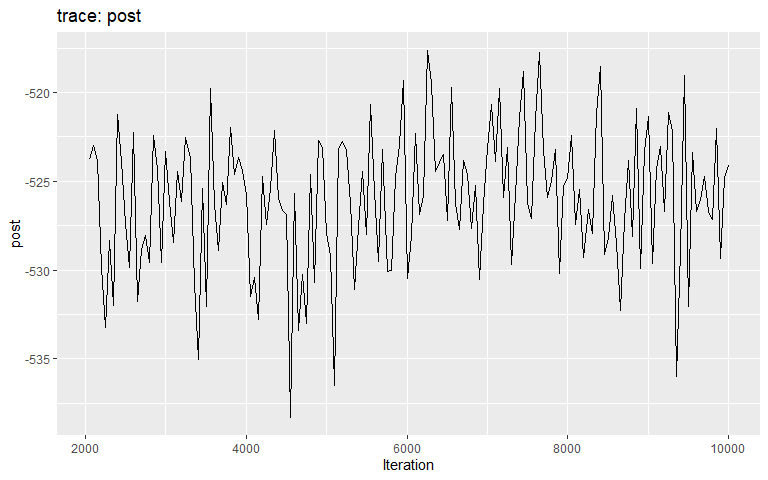

```r
## compare this to plot(res)
plot(res, burnin = 2000)
```

`type` indicates the type of graphic to plot; roughly:

- `trace` for traces of the MCMC (default)
- `hist`, `density` to assess distributions of quantitative values
- `alpha`, `network` to visualise ancestries / transmission tree; note that `network` opens up an interactive plot and requires a web browser with Javascript enabled; the argument `min_support` is useful to select only the most supported ancestries and avoid displaying too many links
- `kappa` to visualise the distributions generations between cases and their ancestor / infector

Here are a few examples:

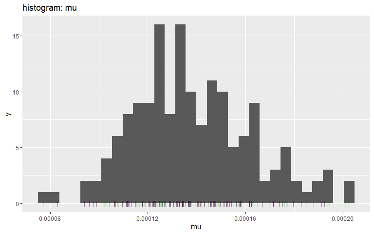

```r
plot(res, "mu", "hist", burnin = 2000)
```

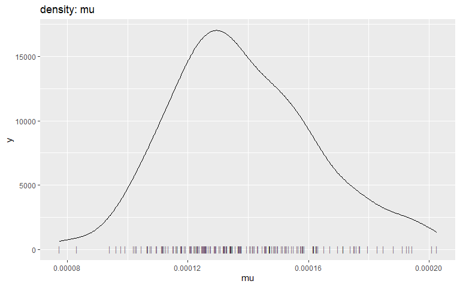

```r
plot(res, "mu", "density", burnin = 2000)
```

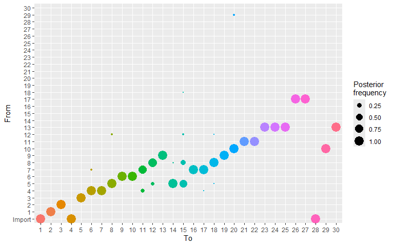

```r
plot(res, type = "alpha", burnin = 2000)
```

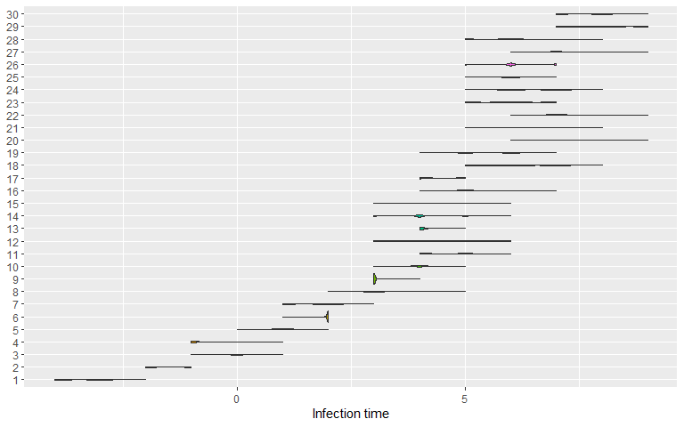

```r
plot(res, type = "t_inf", burnin = 2000)
```

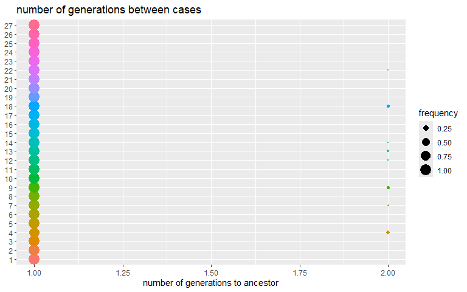

```r
plot(res, type = "kappa", burnin = 2000)
```

```r
plot(res, type = "network", burnin = 2000, min_support = 0.01)
```

[interactive chart not shown]

## Using `summary`

The summary of results derives various distributional statistics for posterior, likelihood and prior densities, as well as for the quantitative parameters. It also builds a consensus tree, by finding for each case the most frequent infector / ancestor in the posterior samples. The corresponding frequencies are reported as ‘support’. The most frequent value of kappa is also reported as ‘generations’:

```r
summary(res)
```

```
#> $step
#>    first     last interval  n_steps
#>        1    10000       50      201
#>
#> $post
#>    Min. 1st Qu.  Median    Mean 3rd Qu.    Max.
#> -1197.9  -528.8  -525.9  -529.6  -523.3  -517.7
#>
#> $like
#>    Min. 1st Qu.  Median    Mean 3rd Qu.    Max.
#> -1199.3  -530.8  -528.0  -531.5  -525.4  -519.7
#>
#> $prior
#>    Min. 1st Qu.  Median    Mean 3rd Qu.    Max.
#>  0.4784  1.8653  2.0646  1.9781  2.1989  2.2985
#>
#> $mu
#>      Min.   1st Qu.    Median      Mean   3rd Qu.      Max.
#> 7.731e-05 1.218e-04 1.345e-04 1.371e-04 1.514e-04 2.025e-04
#>
#> $pi
#>    Min. 1st Qu.  Median    Mean 3rd Qu.    Max.
#>  0.8165  0.9526  0.9739  0.9651  0.9886  0.9996
#>
#> $tree
#>    from to time   support generations
#> 1    NA  1   -4        NA          NA
#> 2     1  2   -2 1.0000000           1
#> 3     2  3    0 1.0000000           1
#> 4    NA  4   -1        NA          NA
#> 5     3  5    1 1.0000000           1
#> 6     4  6    2 0.9601990           1
#> 7     4  7    2 1.0000000           1
#> 8     5  8    3 0.9552239           1
#> 9     6  9    3 0.9900498           1
#> 10    6 10    4 0.9950249           1
#> 11    7 11    4 0.8009950           1
#> 12    8 12    5 0.8308458           1
#> 13    9 13    4 1.0000000           1
#> 14    5 14    4 0.9800995           1
#> 15    5 15    4 0.6716418           1
#> 16    7 16    5 0.9950249           1
#> 17    7 17    4 0.9850746           1
#> 18    8 18    6 0.9850746           1
#> 19    9 19    6 1.0000000           1
#> 20   10 20    7 0.9751244           1
#> 21   11 21    7 1.0000000           1
#> 22   11 22    7 1.0000000           1
#> 23   13 23    6 1.0000000           1
#> 24   13 24    7 1.0000000           1
#> 25   13 25    6 1.0000000           1
#> 26   17 26    6 0.9950249           1
#> 27   17 27    7 1.0000000           1
#> 28   NA 28    6        NA          NA
#> 29   10 29    8 1.0000000           1
#> 30   13 30    7 1.0000000           1
```

# Customising settings and priors

```r
config2 <- create_config(n_iter = 3e4,
                         sample_every = 20,
                 init_tree ="star",
             move_kappa = FALSE,
             prior_mu = 10)

set.seed(1)

res2 <- outbreaker(data, config2)
```

```
#> Identifying imports...
#>   |                                                          |                                                  |   1%  |                                                          |=                                                 |   2%  |                                                          …
#> Reconstructing transmission trees...
#>   |                                                          |                                                  |   0%  |                                                          |                                                  |   1%  |                                                          …
```

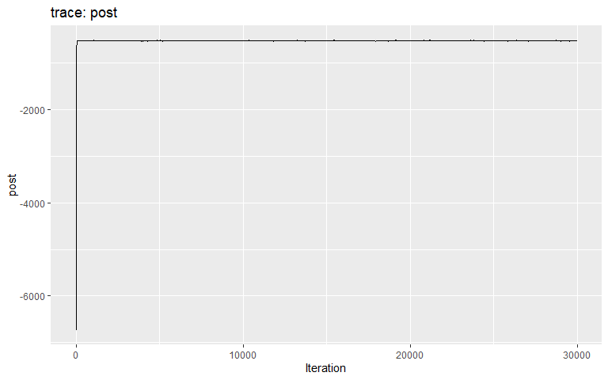

```r
plot(res2)
```

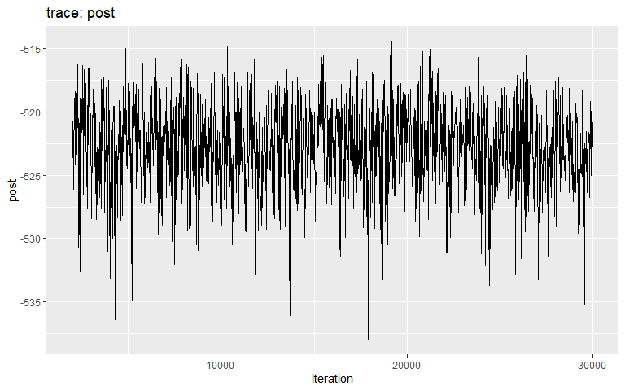

```r
plot(res2, burnin = 2000)
```

We can see that the burnin is around 2,500 iterations (i.e. after the initial step corresponding to a local optimum). We get the consensus tree from the new results, and compare the inferred tree to the actual ancestries stored in the dataset (`fake_outbreak$ances`):

```r
summary(res2, burnin = 3000)
```

```
#> $step
#>    first     last interval  n_steps
#>     3020    30000       20     1350
#>
#> $post
#>    Min. 1st Qu.  Median    Mean 3rd Qu.    Max.
#>  -538.0  -525.0  -522.7  -522.8  -520.4  -514.4
#>
#> $like
#>    Min. 1st Qu.  Median    Mean 3rd Qu.    Max.
#>  -541.9  -529.3  -527.1  -527.2  -524.7  -519.0
#>
#> $prior
#>    Min. 1st Qu.  Median    Mean 3rd Qu.    Max.
#>   2.856   4.270   4.436   4.362   4.531   4.604
#>
#> $mu
#>      Min.   1st Qu.    Median      Mean   3rd Qu.      Max.
#> 7.236e-05 1.211e-04 1.351e-04 1.370e-04 1.506e-04 2.278e-04
#>
#> $pi
#>    Min. 1st Qu.  Median    Mean 3rd Qu.    Max.
#>  0.8235  0.9636  0.9815  0.9738  0.9919  1.0000
#>
#> $tree
#>    from to time   support generations
#> 1    NA  1   -4        NA          NA
#> 2     1  2   -2 1.0000000           1
#> 3     2  3    0 1.0000000           1
#> 4    NA  4   -1        NA          NA
#> 5     3  5    1 0.9992593           1
#> 6     4  6    2 0.9555556           1
#> 7     4  7    2 1.0000000           1
#> 8     5  8    3 0.9540741           1
#> 9     6  9    3 1.0000000           1
#> 10    6 10    4 1.0000000           1
#> 11    7 11    4 0.8214815           1
#> 12    8 12    5 0.8266667           1
#> 13    9 13    4 1.0000000           1
#> 14    5 14    4 0.9911111           1
#> 15    5 15    4 0.7437037           1
#> 16    7 16    5 0.9962963           1
#> 17    7 17    4 0.9814815           1
#> 18    8 18    6 0.9822222           1
#> 19    9 19    6 1.0000000           1
#> 20   10 20    7 0.9777778           1
#> 21   11 21    7 1.0000000           1
#> 22   11 22    7 1.0000000           1
#> 23   13 23    6 1.0000000           1
#> 24   13 24    7 1.0000000           1
#> 25   13 25    6 1.0000000           1
#> 26   17 26    6 1.0000000           1
#> 27   17 27    7 1.0000000           1
#> 28   NA 28    6        NA          NA
#> 29   10 29    8 1.0000000           1
#> 30   13 30    8 1.0000000           1
```

```r
tree2 <- summary(res2, burnin = 3000)$tree

comparison <- data.frame(case = 1:30,
                         inferred = paste(tree2$from),
             true = paste(fake_outbreak$ances),
             stringsAsFactors = FALSE)

comparison$correct <- comparison$inferred == comparison$true
comparison
```

```
#>    case inferred true correct
#> 1     1       NA   NA    TRUE
#> 2     2        1    1    TRUE
#> 3     3        2    2    TRUE
#> 4     4       NA   NA    TRUE
#> 5     5        3    3    TRUE
#> 6     6        4    4    TRUE
#> 7     7        4    4    TRUE
#> 8     8        5    5    TRUE
#> 9     9        6    6    TRUE
#> 10   10        6    6    TRUE
#> 11   11        7    7    TRUE
#> 12   12        8    8    TRUE
#> 13   13        9    9    TRUE
#> 14   14        5    5    TRUE
```

[output cut: 16 more lines]

```r
mean(comparison$correct)
```

```
#> [1] 1
```

Let’s visualise the posterior trees:

```r
plot(res2, type = "network", burnin = 3000, min_support = 0.01)
```

[interactive chart not shown]